# MCAR, MAR, and MNAR: A Decision Framework

Classifying Missing Data Mechanisms in Longitudinal Studies

## 1. The Three Mechanisms

Understanding the mechanism behind missing data is crucial for selecting appropriate analysis methods. The three mechanisms differ in what the probability of missingness depends on.

### Formal Definitions

Let $R$ be the missingness indicator (1 = observed, 0 = missing), $Y_{obs}$ be the observed data, and $Y_{mis}$ be the missing data.

| Mechanism | Formal Definition | Plain English | Example |
| --- | --- | --- | --- |
| **MCAR** | $P(R \mid Y_{obs}, Y_{mis}) = P(R)$ | Missingness is completely random; unrelated to any data | Lab machine randomly malfunctions |
| **MAR** | $P(R \mid Y_{obs}, Y_{mis}) = P(R \mid Y_{obs})$ | Missingness depends only on **observed** data | Sicker patients drop out, but severity was recorded |
| **MNAR** | $P(R \mid Y_{obs}, Y_{mis})$ depends on $Y_{mis}$ | Missingness depends on the **unobserved** values themselves | Patients skip visits because of unmeasured weight gain |

### Key Distinctions

- **MCAR**: The “gold standard” that rarely holds in practice
- **MAR**: The most common assumption; requires careful covariate collection
- **MNAR**: The most problematic; requires strong assumptions or sensitivity analysis

**WarningCommon Misconception**

The word “random” in MAR does NOT mean the same as “completely random.” MAR means missingness can be predicted by observed variables, making it systematically (not randomly!) related to the data.

## 2. Visual Intuition

### Dependency Structure Diagram

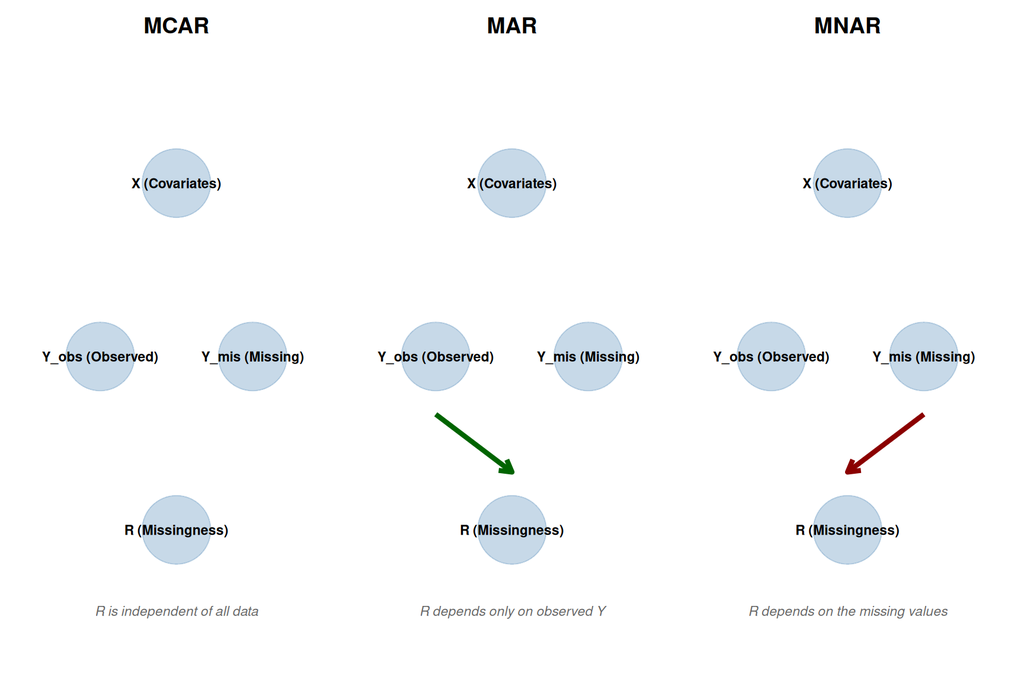

Figure 1: Dependency structure for the three missing data mechanisms

### Decision Tree: Classifying Your Missing Data

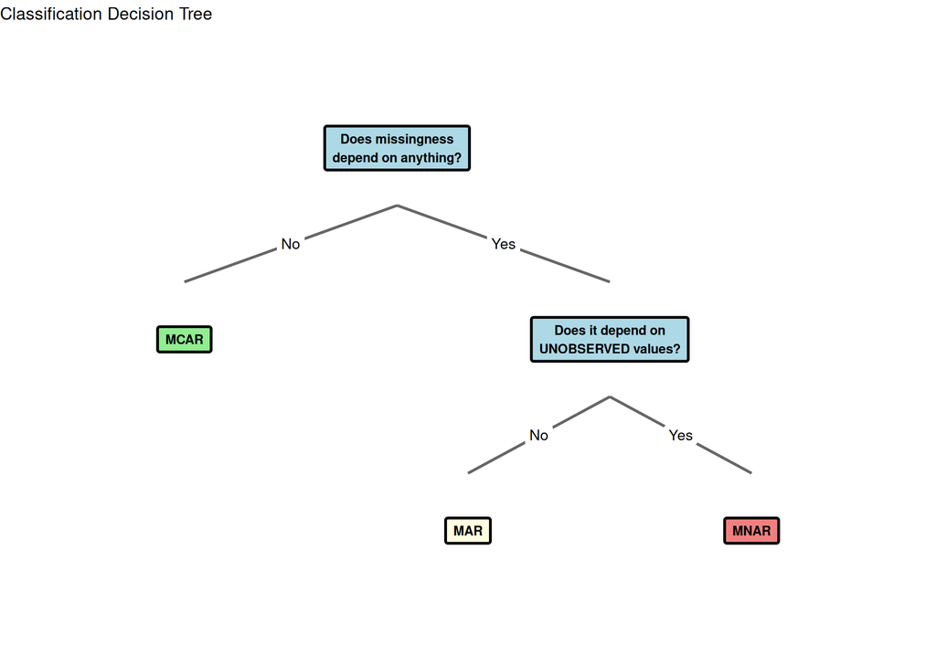

Figure 2: Decision tree for classifying missing data mechanisms

## 3. Classification Examples

The following table provides practical scenarios to help you classify missing data mechanisms:

| Scenario | Classification | Why |
| --- | --- | --- |
| Lab machine randomly malfunctions | **MCAR** | Missingness unrelated to patient characteristics or outcomes |
| Sicker patients drop out, but baseline severity was recorded | **MAR** | Missingness depends on observed severity (can be modeled) |
| Patients embarrassed by weight gain skip weight measurements | **MNAR** | Missingness depends on the actual (unobserved) weight |
| Depressed patients miss visits; depression was measured at baseline | **MAR** | Missingness predictable from observed depression scores |
| Depressed patients miss visits; depression was NOT measured | **MNAR** | The predictor of missingness is unobserved |
| Survey respondents skip income questions based on education level | **MAR** | If education is observed, missingness can be modeled |
| High earners refuse to report income | **MNAR** | Missingness depends on the actual (missing) income values |
| Random sampling failure (data corruption) | **MCAR** | Technical failure unrelated to data values |
| Patients with side effects stop treatment and drop out; side effects recorded | **MAR** | Side effect status is observed and can predict dropout |

**TipThe Key Question**

Ask yourself: “If I knew the missing values, would that help me predict who is missing?”

- **No** $\rightarrow$ MCAR or MAR
- **Yes** $\rightarrow$ MNAR

## 4. Method Validity Table

Different analysis methods have different validity under each mechanism:

| Method | MCAR | MAR | MNAR | Notes |
| --- | --- | --- | --- | --- |
| Complete case analysis | $\checkmark$ | Biased | Biased | Valid only under MCAR; loses efficiency |
| Available case (pairwise deletion) | $\checkmark$ | Sometimes | Biased | May produce non-positive-definite covariance matrices |
| GEE (standard) | $\checkmark$ | Biased | Biased | Requires MCAR for valid inference |
| Mixed models (ML/REML) | $\checkmark$ | $\checkmark$ | Biased | Valid under MAR if model correctly specified |
| Multiple imputation | $\checkmark$ | $\checkmark$ | Biased | Requires proper imputation model |
| Inverse probability weighted GEE | $\checkmark$ | $\checkmark$ | Biased | Requires correct weight model |
| Pattern-mixture models | $\checkmark$ | $\checkmark$ | $\checkmark$* | *If pattern correctly specified |
| Selection models | $\checkmark$ | $\checkmark$ | $\checkmark$* | *If selection mechanism correctly specified |

**ImportantCritical Point**

No method can “fix” MNAR without additional assumptions. Pattern-mixture and selection models require specifying the relationship between missingness and the missing values, which cannot be verified from the observed data alone.

### Visual Summary

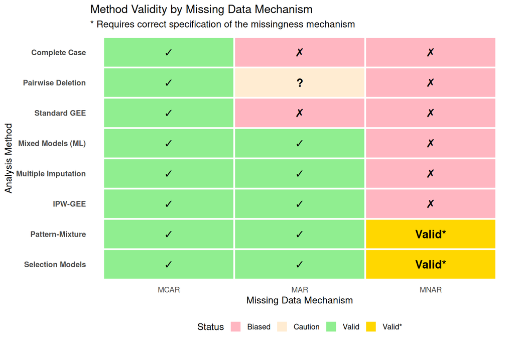

Figure 3: Method validity under different missing data mechanisms

## 5. The Golden Rule

**NoteThe MAR Definition**

**MAR means missingness depends on OBSERVED data only.**

Given the observed data, the probability of being missing does not depend on the actual missing values.

### Common Mistakes

**WarningMistake 1: “Random” = MCAR**

Many researchers assume MAR means data is “randomly missing.” This is incorrect! Under MAR, missingness can be highly systematic and predictable, as long as the predictors are observed.

**Example**: If older patients always drop out earlier, this is MAR (not MCAR) as long as age is recorded.

**WarningMistake 2: Not Including Predictors of Missingness**

If a variable predicts missingness and you do not include it in your model, you effectively convert MAR to MNAR.

**Solution**: Always include variables that predict dropout in your analysis model.

**WarningMistake 3: Assuming You Can Test for MNAR**

MNAR cannot be tested directly because it involves unobserved data. You can test MCAR vs. not-MCAR, but you cannot distinguish MAR from MNAR using observed data alone.

**Solution**: Use sensitivity analyses to assess robustness to MNAR assumptions.

## 6. Simulation Demonstration

### Setup: MAR Dropout Based on Previous Value

```r
set.seed(667)

# Simulation parameters
n_subjects <- 200     # Number of subjects
n_times <- 5          # Number of time points
n_sims <- 500         # Number of simulations
beta_true <- 2        # True time effect

# Function to generate data with MAR dropout
generate_mar_data <- function(n_subjects, n_times, beta_true) {

  # Generate complete data
  data <- expand.grid(
    time = 1:n_times,
    subject = 1:n_subjects
  ) |>
    arrange(subject, time) |>
    group_by(subject) |>
    mutate(
      # Random intercept
      b0 = rnorm(1, 0, sd = 3)[1],
      # Outcome: Y = 10 + 2*time + b0 + error
      y_complete = 10 + beta_true * time + b0 + rnorm(n(), 0, 2)
    ) |>
    ungroup()

  # Create MAR dropout based on PREVIOUS observed value
  # Higher values at time t-1 -> more likely to drop at time t
  data <- data |>
    group_by(subject) |>
    mutate(
      y_lag = lag(y_complete),
      # Probability of dropout increases with previous Y
      # Using logistic model: logit(P(dropout)) = -5 + 0.3 * y_lag
      p_dropout = ifelse(is.na(y_lag), 0, plogis(-5 + 0.3 * y_lag)),
      # Once dropped, stay dropped (monotone missingness)
      dropout = cumsum(runif(n()) < p_dropout) > 0,
      # First observation always observed
      dropout = ifelse(time == 1, FALSE, dropout),
      # Create observed Y
      y_obs = ifelse(dropout, NA, y_complete)
    ) |>
    ungroup()

  return(data)
}

# Generate one dataset to show
example_data <- generate_mar_data(n_subjects, n_times, beta_true)

# Show missingness pattern
cat("Example Missingness Summary:\n")
```

```
Example Missingness Summary:
```

```r
example_data |>
  group_by(time) |>
  summarize(
    n_observed = sum(!is.na(y_obs)),
    pct_observed = round(100 * mean(!is.na(y_obs)), 1)
  ) |>
  print()
```

```
# A tibble: 5 × 3
   time n_observed pct_observed
  <int>      <int>        <dbl>
1     1        200        100
2     2        147         73.5
3     3        102         51
4     4         62         31
5     5         31         15.5
```

### Visualize the MAR Mechanism

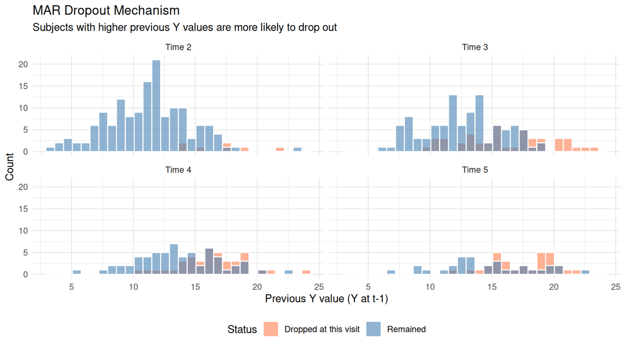

Figure 4: MAR dropout: higher previous values lead to more dropout

```r
# Show relationship between previous Y and dropout
dropout_viz <- example_data |>
  filter(time > 1, !is.na(y_lag)) |>
  mutate(
    status = ifelse(dropout & lag(dropout) == FALSE, "Dropped at this visit",
                    ifelse(dropout, "Already dropped", "Remained"))
  ) |>
  filter(status != "Already dropped")

ggplot(dropout_viz, aes(x = y_lag, fill = status)) +
  geom_histogram(position = "identity", alpha = 0.6, bins = 30, color = "white") +
  facet_wrap(~paste("Time", time)) +
  scale_fill_manual(values = c("Dropped at this visit" = "coral",
                               "Remained" = "steelblue")) +
  labs(x = "Previous Y value (Y at t-1)",
       y = "Count",
       fill = "Status",
       title = "MAR Dropout Mechanism",
       subtitle = "Subjects with higher previous Y values are more likely to drop out") +
  theme_minimal(base_size = 11) +
  theme(legend.position = "bottom")
```

### Run Simulation: Compare Methods

```r
# Storage for results
results <- data.frame(
  sim = integer(),
  method = character(),
  estimate = numeric(),
  se = numeric()
)

# Run simulations
for (s in 1:n_sims) {

  # Generate data
  sim_data <- generate_mar_data(n_subjects, n_times, beta_true)
  sim_data$subject <- factor(sim_data$subject)

  # Method 1: Complete case analysis (only subjects with all observations)
  complete_subjects <- sim_data |>
    group_by(subject) |>
    summarize(complete = all(!is.na(y_obs))) |>
    filter(complete) |>
    pull(subject)

  cc_data <- sim_data |>
    filter(subject %in% complete_subjects)

  if (nrow(cc_data) > 10) {
    fit_cc <- tryCatch({
      lme(y_obs ~ time, random = ~ 1 | subject, data = cc_data, method = "REML")
    }, error = function(e) NULL)

    if (!is.null(fit_cc)) {
      results <- rbind(results, data.frame(
        sim = s,
        method = "Complete Case",
        estimate = fixef(fit_cc)["time"],
        se = sqrt(vcov(fit_cc)["time", "time"])
      ))
    }
  }

  # Method 2: Mixed model using all available data
  fit_mm <- tryCatch({
    lme(y_obs ~ time, random = ~ 1 | subject,
        data = sim_data, na.action = na.omit, method = "REML")
  }, error = function(e) NULL)

  if (!is.null(fit_mm)) {
    results <- rbind(results, data.frame(
      sim = s,
      method = "Mixed Model",
      estimate = fixef(fit_mm)["time"],
      se = sqrt(vcov(fit_mm)["time", "time"])
    ))
  }
}

# Summarize results
summary_results <- results |>
  group_by(method) |>
  summarize(
    n_sims = n(),
    mean_estimate = mean(estimate),
    sd_estimate = sd(estimate),
    bias = mean(estimate) - beta_true,
    pct_bias = 100 * (mean(estimate) - beta_true) / beta_true,
    mean_se = mean(se),
    coverage = mean(abs(estimate - beta_true) < 1.96 * se)
  )

cat("True time effect (beta):", beta_true, "\n\n")
```

```
True time effect (beta): 2
```

```r
print(summary_results)
```

```
# A tibble: 2 × 8
  method      n_sims mean_estimate sd_estimate    bias pct_bias mean_se coverage
  <chr>        <int>         <dbl>       <dbl>   <dbl>    <dbl>   <dbl>    <dbl>
1 Complete C…    500          2.00      0.109  4.62e-3   0.231   0.108     0.948
2 Mixed Model    500          2.00      0.0808 8.53e-4   0.0426  0.0801    0.952
```

### Visualize Results

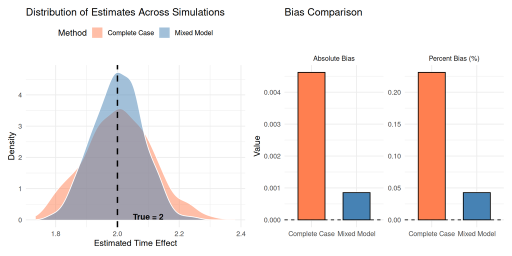

Figure 5: Simulation results: Complete case vs. Mixed model under MAR

```r
# Density plot of estimates
p1 <- ggplot(results, aes(x = estimate, fill = method)) +
  geom_density(alpha = 0.5, color = "white") +
  geom_vline(xintercept = beta_true, linetype = "dashed", linewidth = 1, color = "black") +
  annotate("text", x = beta_true + 0.05, y = 0.1, label = paste("True =", beta_true),
           hjust = 0, size = 4, fontface = "bold") +
  scale_fill_manual(values = c("Complete Case" = "coral", "Mixed Model" = "steelblue")) +
  labs(x = "Estimated Time Effect",
       y = "Density",
       fill = "Method",
       title = "Distribution of Estimates Across Simulations") +
  theme_minimal(base_size = 12) +
  theme(legend.position = "top")

# Bias comparison
bias_data <- summary_results |>
  select(method, bias, pct_bias) |>
  pivot_longer(cols = c(bias, pct_bias), names_to = "metric", values_to = "value") |>
  mutate(metric = ifelse(metric == "bias", "Absolute Bias", "Percent Bias (%)"))

p2 <- ggplot(bias_data, aes(x = method, y = value, fill = method)) +
  geom_col(width = 0.6, color = "black") +
  geom_hline(yintercept = 0, linetype = "dashed") +
  facet_wrap(~metric, scales = "free_y") +
  scale_fill_manual(values = c("Complete Case" = "coral", "Mixed Model" = "steelblue")) +
  labs(x = "", y = "Value", title = "Bias Comparison") +
  theme_minimal(base_size = 12) +
  theme(legend.position = "none")

p1 + p2
```